# R Notebook

### Quantitative predictors

#### Displacement vs MPG Scatterplot

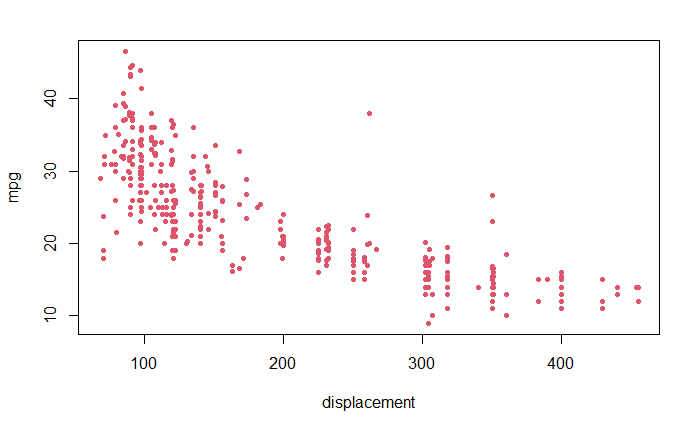

#### Horsepower vs MPG Scatterplot

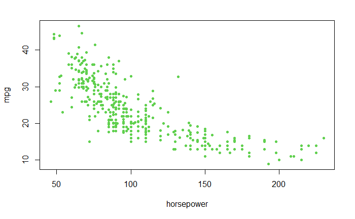

#### Weight vs MPG Scatterplot

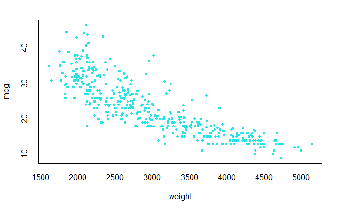

#### Acceleration vs MPG Scatterplot

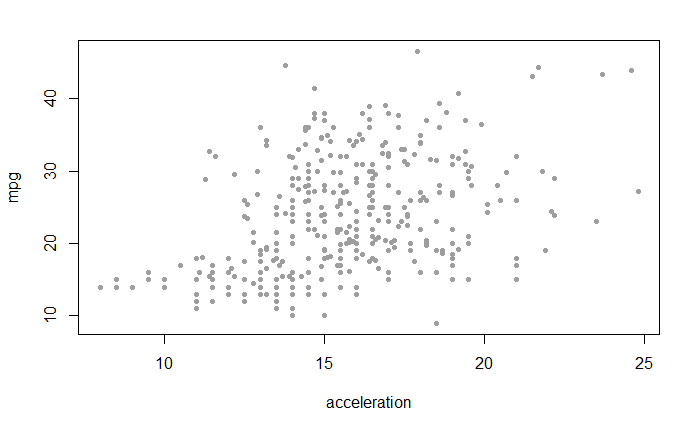

### Qualitative predictors

#### Cylinder Histogram

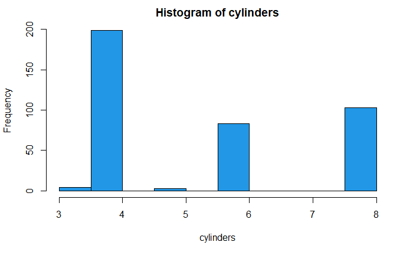

#### Year Histogram

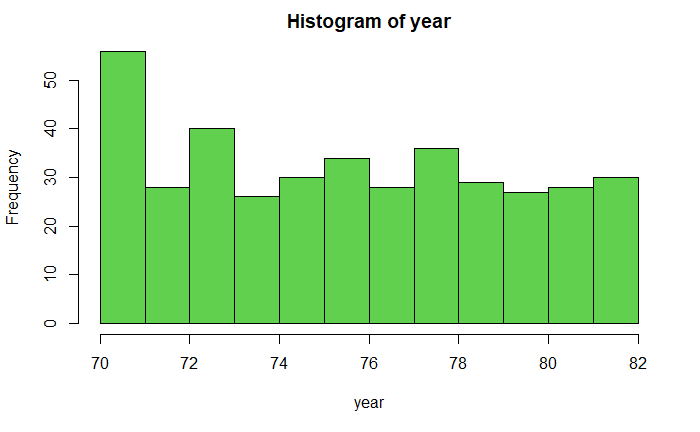

#### Origin histogram

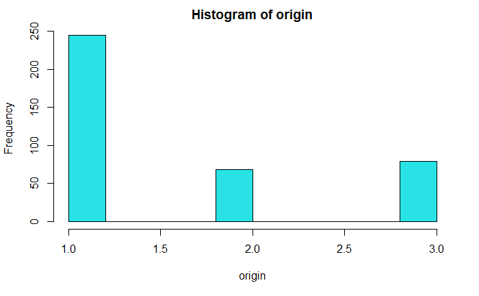

This exercise involves the `Boston` housing data set.

a)To begin, load in the `Boston` data set. The `Boston` data set is part of the `MASS` **library** in `R`.

Now the data set is contained in the object `Boston`.

|  | crim | zn | indus | chas | nox | rm | age | dis | rad | tax | ptratio | black | lstat | medv |
| --- | --- | --- | --- | --- | --- | --- | --- | --- | --- | --- | --- | --- | --- | --- |
| 1 | 0.00632 | 18.0 | 2.31 | 0 | 0.5380 | 6.575 | 65.2 | 4.0900 | 1 | 296 | 15.3 | 396.90 | 4.98 | 24.0 |
| 2 | 0.02731 | 0.0 | 7.07 | 0 | 0.4690 | 6.421 | 78.9 | 4.9671 | 2 | 242 | 17.8 | 396.90 | 9.14 | 21.6 |
| 3 | 0.02729 | 0.0 | 7.07 | 0 | 0.4690 | 7.185 | 61.1 | 4.9671 | 2 | 242 | 17.8 | 392.83 | 4.03 | 34.7 |
| 4 | 0.03237 | 0.0 | 2.18 | 0 | 0.4580 | 6.998 | 45.8 | 6.0622 | 3 | 222 | 18.7 | 394.63 | 2.94 | 33.4 |
| 5 | 0.06905 | 0.0 | 2.18 | 0 | 0.4580 | 7.147 | 54.2 | 6.0622 | 3 | 222 | 18.7 | 396.90 | 5.33 | 36.2 |
| 6 | 0.02985 | 0.0 | 2.18 | 0 | 0.4580 | 6.430 | 58.7 | 6.0622 | 3 | 222 | 18.7 | 394.12 | 5.21 | 28.7 |
| 7 | 0.08829 | 12.5 | 7.87 | 0 | 0.5240 | 6.012 | 66.6 | 5.5605 | 5 | 311 | 15.2 | 395.60 | 12.43 | 22.9 |
| 8 | 0.14455 | 12.5 | 7.87 | 0 | 0.5240 | 6.172 | 96.1 | 5.9505 | 5 | 311 | 15.2 | 396.90 | 19.15 | 27.1 |
| 9 | 0.21124 | 12.5 | 7.87 | 0 | 0.5240 | 5.631 | 100.0 | 6.0821 | 5 | 311 | 15.2 | 386.63 | 29.93 | 16.5 |
| 10 | 0.17004 | 12.5 | 7.87 | 0 | 0.5240 | 6.004 | 85.9 | 6.5921 | 5 | 311 | 15.2 | 386.71 | 17.10 | 18.9 |

[output cut: 496 more lines]

Read about the data set

2. Make some pairwise scatterplots of the predictors (columns) in this data set

```r
a <- [1:6]
```

```
Error: unexpected '[' in "a <- ["
```

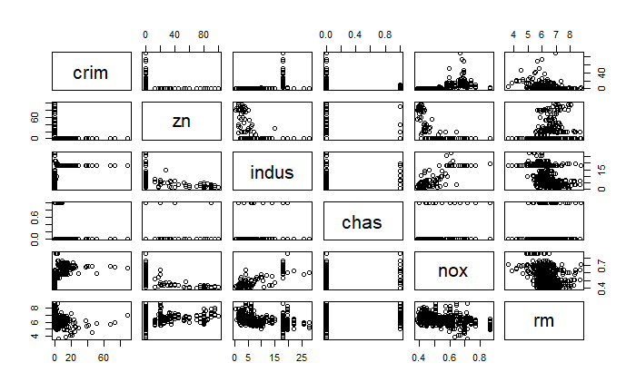

```r
append(b, 1, after = F)
```

```
[1]  1  7  8  9 10
```

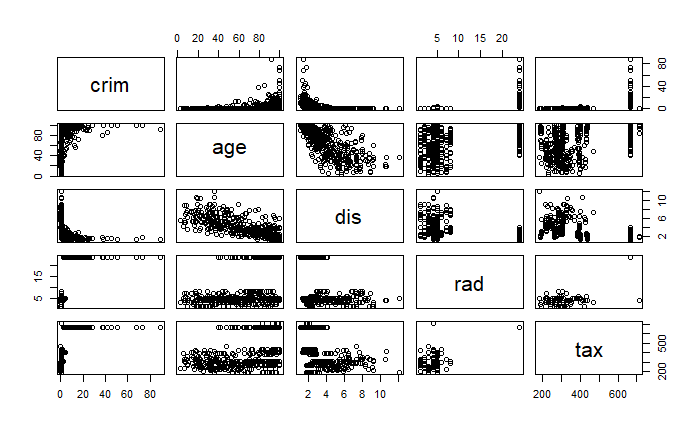

```r
c <- append(1, 11_14, after=F)
```

```
Error: unexpected input in "c <- append(1, 11_"
```

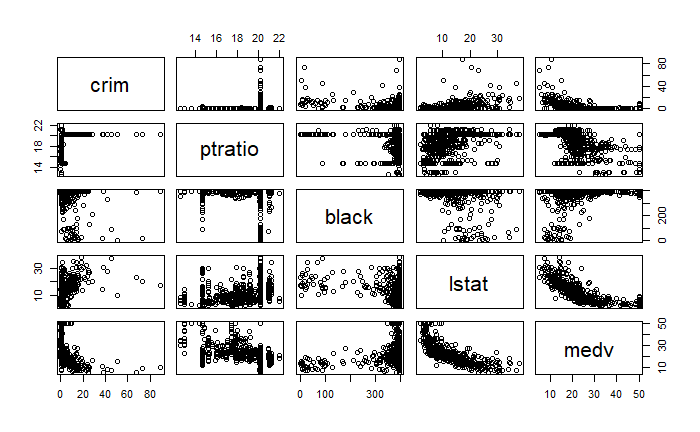

Now let’s have a look about the data in this data set, whether there are some qualitative predictors and which are.

```r
numberUniqueValues = sapply(apply(Boston, 2, unique), FUN = length))
```

```
Error: unexpected ')' in "numberUniqueValues = sapply(apply(Boston, 2, unique), FUN = length))"
```

```r
numberUniqueValues
```

```
   crim      zn   indus    chas     nox      rm     age     dis     rad     tax ptratio   black   lstat
    504      26      76       2      81     446     356     412       9      66      46     357     455
   medv
    229
```

As we can see, some candidates that can be used as qualitative predictors are `` rad`` and ``chas`, even`zn` but this last one will depend directly of capacity computing we have.

How many of the subsets in this data set bound the Charles river (1 if tract bounds river, 0 otherwise)?

```r
summary(Boston$chas)
```

```
  0   1
471  35
```

What is the median pupil-teacher ratio among the towns in this data set?

```r
median(Boston$ptratio)
```

```
[1] 19.05
```

Which suburb of Boston has lowest median value of owners occupied homes? What are the values of the other predictors for that suburb, and how do those values compare to the overall ranges for those predictors?

```r
which.min(Boston$medv)
```

```
[1] 399
```

|  | crim | zn | indus | chas | nox | rm | age | dis | rad | tax | ptratio | black | lstat | medv |
| --- | --- | --- | --- | --- | --- | --- | --- | --- | --- | --- | --- | --- | --- | --- |
| 399 | 38.3518 | 0 | 18.1 | 0 | 0.693 | 5.453 | 100 | 1.4896 | 24 | 666 | 20.2 | 396.9 | 30.59 | 5 |

We can create an array to save the ranges for each predictor from this data set.

```r
ranges <- sapply(Boston, fun(x){
```

```
Error: unexpected '{' in "ranges <- sapply(Boston, fun(x){"
```

```r
ranges <- ranges[!sapply(x, is.null)]
```

```
Error in lapply(X = X, FUN = FUN, ...) : object 'x' not found
```

Now, let’s to create a new variable called `quantitativeNames` where we will save each quantitative predictor

```r
quantitativeNames
```

```
Error: object 'quantitativeNames' not found
```

```r
ranges$medv[2]
```

```
[1] 50
```

```r
for(name in quantitativeNames){

    predictor <- Boston[indexMinmedv,name]
    limInf <- ranges[[name]][1]
    limSup <- ranges[[name]][2]
    cat("The predictor value is:",predictor,"and the range is:",limInf,"-",limSup,"\n")
    }
```

```
The predictor value is: 38.3518 and the range is: 0.00632 - 88.9762
The predictor value is: 0 and the range is: 0 - 100
The predictor value is: 18.1 and the range is: 0.46 - 27.74
The predictor value is: 0.693 and the range is: 0.385 - 0.871
The predictor value is: 5.453 and the range is: 3.561 - 8.78
The predictor value is: 100 and the range is: 2.9 - 100
The predictor value is: 1.4896 and the range is: 1.1296 - 12.1265
The predictor value is: 666 and the range is: 187 - 711
The predictor value is: 20.2 and the range is: 12.6 - 22
The predictor value is: 396.9 and the range is: 0.32 - 396.9
The predictor value is: 30.59 and the range is: 1.73 - 37.97
The predictor value is: 5 and the range is: 5 - 50
```

In this data set, how many of the suburbs average more than seven rooms per dwelling? More than eight per dwelling?

For the suburbs with an average more than seven rooms per dwelling:

```r
length(which(Boston$rm > 7))
```

```
[1] 64
```

For the suburbs with an average more than eigth rooms per dwelling:

```r
length(which(Boston$rm > 8))
```

```
[1] 13
```